# 1.4 — Utility Maximization — Practice Problems (Solutions)

ECON 306

### 1. Suppose you can watch movies in the theater ($t$) and streaming at home ($s$), and earn utility according to the utility function:

$$u(t,s)=4ts$$

Where your marginal utilities are:
$$\begin{aligned}
MU_t&=4s\\
MU_s&=4t\\ \end{aligned}$$

#### a. Put $t$ on the horizontal axis and $s$ on the vertical axis. Write an equation for $MRS_{t,s}$

$$\begin{align*}
MRS_{t,s}&=\frac{MU_t}{MU_s}\\
&=\frac{4s}{4t}\\
&=\frac{s}{t}\\
\end{align*}$$

#### b. Would bundles of $(2,2)$ and $(1,4)$ be on the same indifference curve?

Simply plug in each bundle to see how much utility it generates. If they have the same utility, they are on the same indifference curve.

$$\begin{align*}
u(t,s)&=4ts\\
u(2,2)&=4(2)(2)\\
u(2,2)&=16\\
\end{align*}$$

$$\begin{align*}
u(t,s)&=4ts\\
u(1,4)&=4(1)(4)\\
u(1,4)&=16\\
\end{align*}$$

Since both bundles generate utility of 16, they are both on the same curve.

#### c. Sketch this indifference curve.

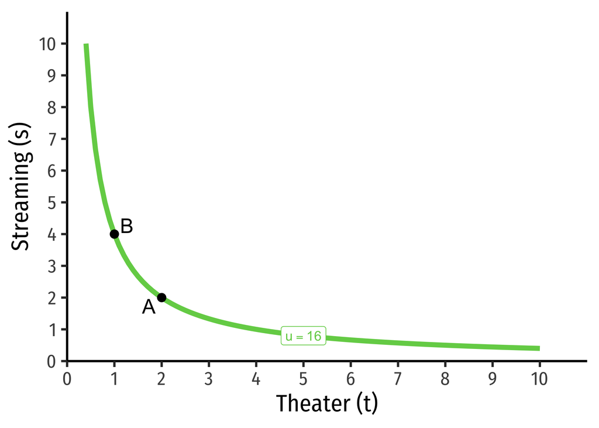

### 2. You can get utility from consuming Soda $(s)$ and Hot dogs $(h)$, according to the utility function:

$$u(s,h)=\sqrt{sh}$$

The marginal utilities are:

$$\begin{aligned}
MU_s&=0.5s^{-0.5}h^{0.5} \\
MU_h&=0.5s^{0.5}h^{-0.5} \\ \end{aligned}$$

You have an income of $12, the price of Soda is $2, and the price of a Hot dog is $3. Put Soda on the horizontal axis and Hot dogs on the vertical axis.

#### a. What is your utility-maximizing bundle of Soda and Hot dogs?

Use the definition of the optimum, where the slope of the indifference curve (left) is equal to the slope of the brudget constraint (right):

$$\begin{align*}
MRS_{s,h}&=\frac{p_s}{p_h} & & \text{Definition of the optimum}\\
\frac{MU_s}{MU_h}&=\frac{p_s}{p_h} && \text{Definition of MRS on left}\\
\frac{0.5s^{-0.5}h^{0.5}}{0.5s^{0.5}h^{-0.5}}&=\frac{(2)}{(3)} & & \text{Plugging in what we know}\\
\frac{0.5}{0.5}s^{(-0.5-0.5)}h^{(0.5-[-0.5])} &=\frac{2}{3} && \text{Using exponent rules for division}\\
s^{-1}h^{1} &=\frac{2}{3} && \text{Simplifying and cancelling}\\
\frac{h}{s}&=\frac{2}{3} && \text{Using exponent rules for negative exponents}\\
h&=\frac{2}{3}s && \text{Multiplying both sides by} s\\
\end{align*}$$

To find the exact quantities of $s$ and $h$, plug what we just found into the budget constraint:

$$\begin{align*}
p_ss +p_hh &=m & & \text{The budget constraint equation}\\
2s + 3h &=12 & & \text{Plugging in what we are given}\\
2s + 3(\frac{2}{3}s)&=12 & & \text{Plugging in what we found relating }b \text{ to } a\\
2s+2s&=12 & & \text{Multiplying}\\
4s&=12 & & \text{Adding}\\
s&=3 & & \text{Dividing by } 4\\
\end{align*}$$

Now that we know the quantity of sodas, we can use our knowledge of the ratio of sodas to hot dogs to find the quantity of hot dogs.

$$\begin{align*}
h&=\frac{2}{3}s\\
h&=\frac{2}{3}(3)\\
h&=2\\
\end{align*}$$

#### b. How much utility does this provide?

Plug answers from part A into the utility funtion:

$$\begin{align*}
u(s,h)&=\sqrt{sh}\\
u(s,h)&=\sqrt{(3)(2)}\\
u(s,h)&=\sqrt{6}\\
\end{align*}$$

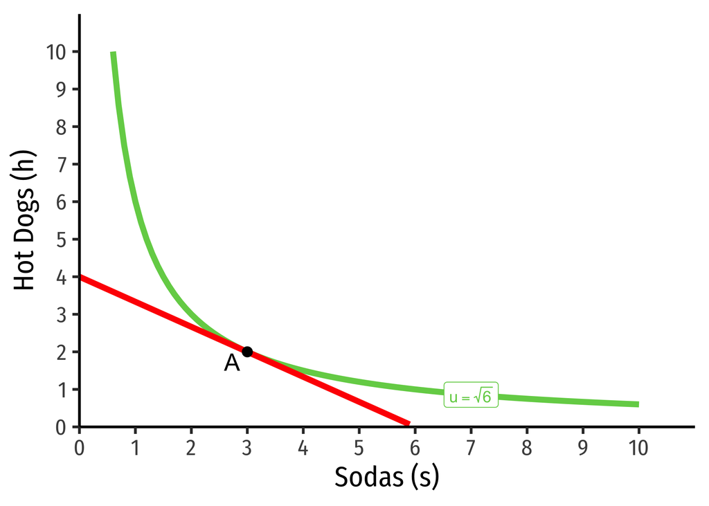